# Rmarkdown_Hazinia

Sara_Hazinia

10/13/2019

Data import

```r
download.file("https://github.com/EEOB-BioData/BCB546X-Fall2019/blob/master/assignments/UNIX_Assignment/fang_et_al_genotypes.txt", destfile = "./fang_et_al.txt")
library(tidyverse)
fang <- read_tsv("./fang_et_al_genotypes.txt")
snp <- read_tsv("./snp_position.txt")
```

Data inspection

We can inspect the dimention of files by using “dim” function and limit the entire file into a short piece of file (10 rows and 5 columns)

```r
dim(fang)
```

```
## [1] 2782  986
```

```r
dim(snp)
```

```
## [1] 983  15
```

```r
fang[1:10, 1:5]
```

```
## # A tibble: 10 x 5
##    Sample_ID JG_OTU   Group abph1.20 abph1.22
##    <chr>     <chr>    <chr> <chr>    <chr>
##  1 SL-15     T-aust-1 TRIPS ?/?      ?/?
##  2 SL-16     T-aust-2 TRIPS ?/?      ?/?
##  3 SL-11     T-brav-1 TRIPS ?/?      ?/?
##  4 SL-12     T-brav-2 TRIPS ?/?      ?/?
##  5 SL-18     T-cund   TRIPS ?/?      ?/?
##  6 SL-2      T-dact-1 TRIPS ?/?      ?/?
##  7 SL-4      T-dact-2 TRIPS ?/?      ?/?
##  8 SL-6      T-dact-3 TRIPS ?/?      ?/?
##  9 SL-7      T-dact-4 TRIPS ?/?      ?/?
## 10 SL-5      T-dact-5 TRIPS ?/?      ?/?
```

```r
snp[1:10, 1:5]
```

```
## # A tibble: 10 x 5
##    SNP_ID   cdv_marker_id Chromosome Position  alt_pos
##    <chr>            <dbl> <chr>      <chr>     <chr>
##  1 abph1.20          5976 2          27403404  <NA>
##  2 abph1.22          5978 2          27403892  <NA>
##  3 ae1.3             6605 5          167889790 <NA>
##  4 ae1.4             6606 5          167889682 <NA>
##  5 ae1.5             6607 5          167889821 <NA>
##  6 an1.4             5982 1          240498509 <NA>
##  7 ba1.6             3463 3          181362952 <NA>
##  8 ba1.9             3466 3          181362666 <NA>
##  9 bt2.5             5983 4          66290049  <NA>
## 10 bt2.7             5985 4          66290994  <NA>
```

Data processing *Redoing Unix assignment.* To see how many groups exist and what are their names, use “unique(filename$variableofinterest)” *Using “filter” we choose the groups of interest and transfer them into a new file that ia transposed by “t()”* Using for loop we merge Maize and Teosinte files with the SNP files (that contains only snp ID, position and chromosome numbers).

```r
unique(fang$Group)
```

```
##  [1] "TRIPS" "ZDIPL" "ZPERR" "ZLUXR" "ZMHUE" "ZMPBA" "ZMPJA" "ZMXCH"
##  [9] "ZMXCP" "ZMXNO" "ZMXNT" "ZMPIL" "ZMXIL" "ZMMLR" "ZMMMR" "ZMMIL"
```

```r
library(tidyverse)
download.file("https://raw.githubusercontent.com/EEOB-BioData/BCB546X-Fall2019/master/assignments/UNIX_Assignment/snp_position.txt", destfile = "./snp_position.txt")

download.file("https://raw.githubusercontent.com/EEOB-BioData/BCB546X-Fall2019/master/assignments/UNIX_Assignment/fang_et_al_genotypes.txt", destfile = "./fang_et_al_genotypes.txt")


fang <- read_tsv("./fang_et_al_genotypes.txt")
snp <- read_tsv("./snp_position.txt")
maize_transposed <- filter(fang, Group %in% c("ZMMLR", "ZMMMR", "ZMMIL")) %>%
  select(-JG_OTU, -Group) %>% column_to_rownames(., var = "Sample_ID") %>% t()%>%
  as.data.frame() %>% rownames_to_column(., var = "SNP_ID")

teosinte_transposed <- filter(fang, Group %in% c("ZMPBA", "ZMPIL", "ZMPJA")) %>%
  select(-JG_OTU, -Group) %>% column_to_rownames(., var = "Sample_ID") %>% t()%>%
  as.data.frame() %>% rownames_to_column(., var = "SNP_ID")

snp_formatted <- snp %>% select(SNP_ID, Chromosome, Position)

maize_merged <- merge(snp_formatted, maize_transposed ) %>%  filter(., Position != "multiple",  Chromosome != "unknown")

teosinte_merged <- merge(snp_formatted, teosinte_transposed) %>%
  filter(., Position != "multiple",  Chromosome != "unknown")

maize_to_be_replaced <- maize_merged %>% as.matrix()
teosinte_to_be_replaced <- teosinte_merged %>% as.matrix()

maize_to_be_replaced[maize_to_be_replaced == "?/?"] <- "-/-"
teosinte_to_be_replaced[teosinte_to_be_replaced == "?/?"] <- "-/-"

maize_to_be_replaced <- as.tibble(maize_to_be_replaced)
```

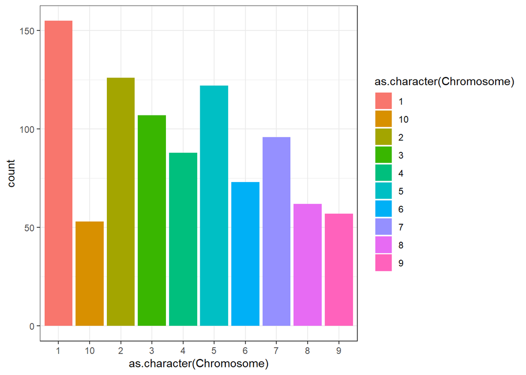

```r
teosinte_to_be_replaced <- as.tibble(teosinte_to_be_replaced)


for (i in 1:10) {

  m1 <- maize_merged %>% filter(., Chromosome == i[1]) %>% arrange(.,as.numeric(Position))
  m2 <- maize_to_be_replaced %>% filter(., Chromosome == i[1]) %>% arrange(.,desc(as.numeric(Position)))

  write_tsv(m1, paste("Maize_chr", i[1], "increasing.txt", sep = "_"))
  write_tsv(m2, paste("Maize_chr", i[1], "decreasing.txt", sep = "_"))

  t1 <- filter(teosinte_merged, Chromosome == i[1]) %>% arrange(., as.numeric(Position))
  t2 <- filter(teosinte_to_be_replaced, Chromosome == i[1]) %>% arrange(., desc(as.numeric(Position)))

  write_tsv(t1, paste("Teosinte_chr", i[1], "_increasing.txt", sep = "_"))
  write_tsv(t2, paste("Teosinte_chr", i[1], "_decreasing.txt", sep = "_"))
}

fang_transposed <- fang %>% select(-JG_OTU, -Group) %>% column_to_rownames(., var = "Sample_ID") %>% t()%>% as.data.frame() %>% rownames_to_column(., var = "SNP_ID")

fang_SNP_merged <- merge(snp_formatted, fang_transposed) %>% filter(., Position !="multiple", Position !="unknown")

ggplot(fang_SNP_merged, aes(x= as.character(Chromosome))) + geom_bar(aes(fill = as.character(Chromosome))) + theme_bw()
```

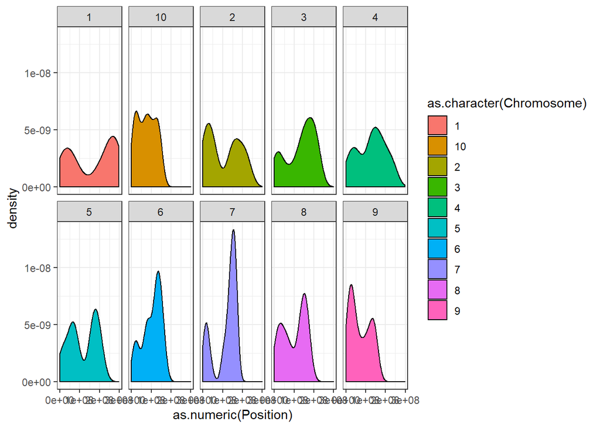

```r
ggplot(fang_SNP_merged, aes(x= as.numeric(Position))) + geom_density(aes(fill = as.character(Chromosome))) + facet_wrap(~ Chromosome, nrow =2, ncol =5) + theme_bw()
```

Graphs

First transpose fang original file by removing two columns that are not necessary (JG_OTU and Group). Now we have SNP ids in rows and sample names in columns.

Formatted sample is reshaping the data into a proper arrangment so we can plot them in stack bar graphs using ggplot.

Data processing part 2

Next, we add a new column called new_sequence in that ,by using ifelse, it will contain the SNPs characters as homo/heterozygous, and missing for unavailable data.

Also, we use position = “fill” to make each bar to fill the entire length of graph. In other words, we standardize the data so we can see how many SNP characters does each sample/group contain.

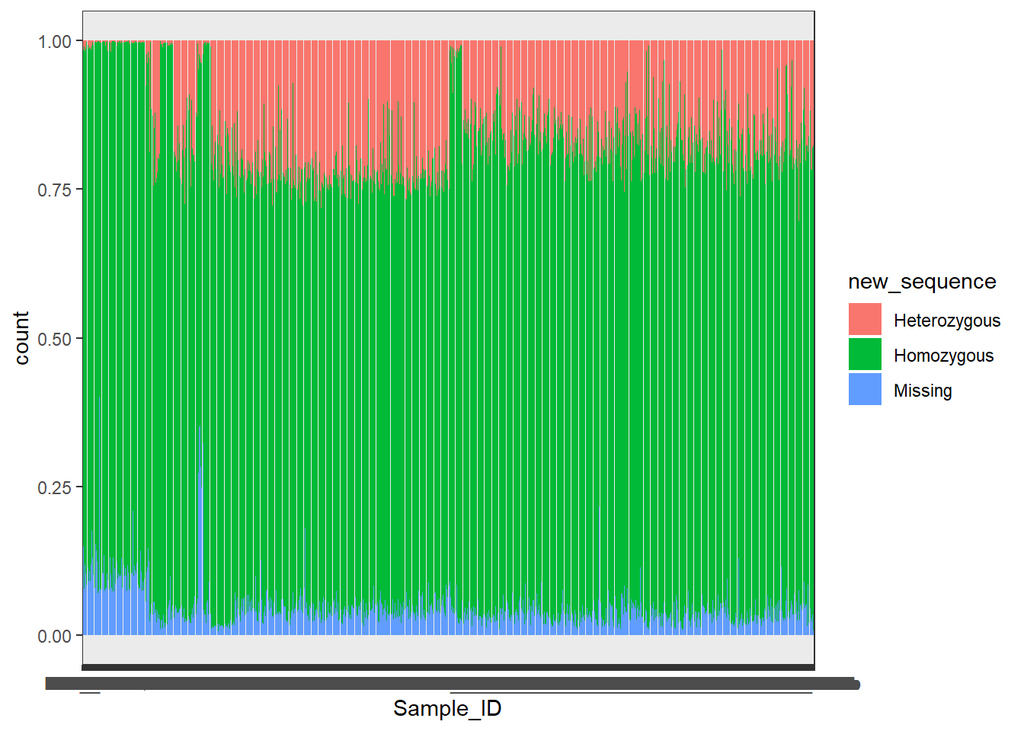

```r
tidy_fang <- fang %>% select(-JG_OTU) %>%
  pivot_longer( -Sample_ID:-Group, names_to = "SNP_ID", values_to = "Sequence")

tidy_fang <- tidy_fang %>%
  mutate(new_sequence = ifelse(Sequence %in% c("A/A","T/T","C/C","G/G"), "Homozygous",
  ifelse(Sequence == "?/?", "Missing","Heterozygous")))

ggplot(tidy_fang, aes(x = Sample_ID, fill = new_sequence)) +
  geom_bar(position = "fill") + theme_bw()
```

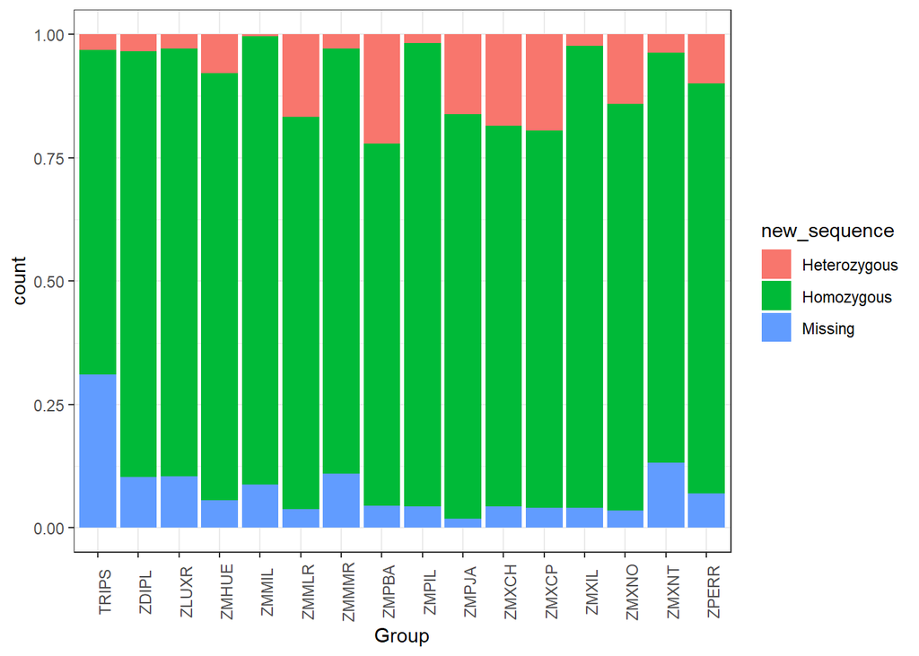

```r
ggplot(tidy_fang, aes(x = Group , fill = new_sequence)) + geom_bar(position = "fill") +
  theme_bw() + theme(axis.text.x = element_text(angle = 90))
```

Below is the visualization of the variables of my interest. I can see for each group, what are the combination of SNPs and which fraction does each SNP occupy.

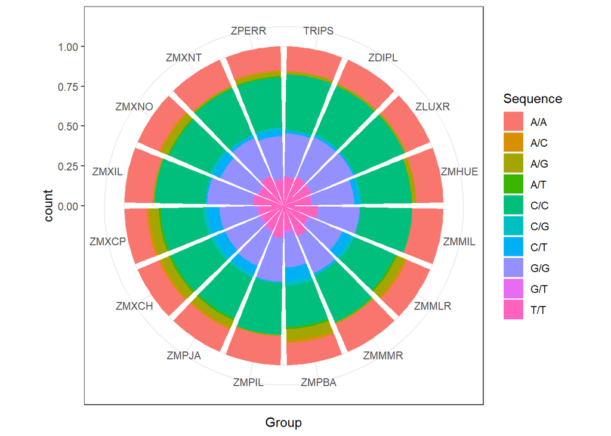

```r
ggplot(filter(tidy_fang, Sequence != "?/?") , aes(x = Group, fill = Sequence)) +
  geom_bar (position = "fill") + coord_polar() +theme_bw()
```